# Project intro to DS

## Install the android/ iOS physics toolbox suite app on your smartphone.

[Physics toolbox suit app on playstore](https://play.google.com/store/apps/details?id=com.chrystianvieyra.physicstoolboxsuite&hl=fr&gl=US)

Use the multiple recording function to record the sensors (Force-g, Linear Accelerometer, Gyroscope) and create 3 files each containing:

- 20 X-movements with 2s pause between each movement
- 20 0-movements with 2s pause between each movement
- 2 min of recording of your daily movements (phone in your pocket or bag for example)

You may find a [Physics suit youtube tutorial](https://www.youtube.com/watch?v=tu6sHeJj4Ys) via this link.

## Create a shiny interface allowing to :

- load a file produced with physics suite
- visualize it (choice of sensors …)
- process it (see details)
- visualize the results of the processing
- export the results of the processing function as a csv files with two additional colums to store labels (X,O,Noise) and group name (Last names of the group members separated with _)

## Details on the processing

1. Create a function `extract_feature_long(data,threeshold_mean,threeshold_sd,threeshold_t)` that:
- compute the norm of the acceleration in three dimension with the gravity removed $gN = |gFx^2+gFy^2+gFz^2-0.8|$
- compute the left rolling average $gNm$ of $gN$ over 10 measurements (see the `RcppRoll` package)
- compute the left rolling standard deviation $gNsd$ of $gN$ over 10 measurements
- filter the data too keep the points where $gNm > threeshold\_mean$ and $gNsd > threeshold\_sd$
- compute $dt_i = time_i-time_{i-1}$
- create an id called $pid$ for each group $g$ of points where $dt_i<threeshold\_time\ , \forall\, i \in g$
- add back the removed point with a pid set to 0

Some example of results are provided below.

```r
library(readr)
data = read_delim("./testSensorT.csv",delim=";",locale = locale(dec=","))
X_long=extract_feature_long(data,0.5,0.2,0.5)
str(X_long)
```

```
FALSE tibble [3,640 × 16] (S3: tbl_df/tbl/data.frame)
FALSE  $ time  : num [1:3640] 0.927 0.927 0.987 0.988 0.99 ...
FALSE  $ gFx   : num [1:3640] -0.0325 -0.0325 -0.0108 0.0649 -0.1227 ...
FALSE  $ gFy   : num [1:3640] -0.0037 -0.0037 -0.0306 -0.0924 -0.0714 ...
FALSE  $ gFz   : num [1:3640] 1.2 1.2 1.22 1.24 1.05 ...
FALSE  $ ax    : num [1:3640] 0.0946 0.0792 0.0792 0.0792 0.0792 ...
FALSE  $ ay    : num [1:3640] 0.0767 -0.082 -0.082 -0.082 -0.082 ...
FALSE  $ az    : num [1:3640] -0.143 -0.692 -0.692 -0.692 -0.692 ...
FALSE  $ wx    : num [1:3640] -1.06 -1.06 -1.06 -1.06 -1.06 ...
FALSE  $ wy    : num [1:3640] -0.0159 -0.0159 -0.0159 -0.0159 -0.0159 ...
FALSE  $ wz    : num [1:3640] 0.226 0.226 0.226 0.226 0.226 ...
FALSE  $ gN    : num [1:3640] 0.63 0.63 0.678 0.758 0.324 ...
FALSE  $ gNm   : num [1:3640] 0.538 0.599 0.659 0.673 0.759 ...
FALSE  $ gNsd  : num [1:3640] 0.313 0.383 0.432 0.435 0.528 ...
FALSE  $ dt    : num [1:3640] NA 0.000641 0.059366 0.001906 0.001216 ...
FALSE  $ switch: num [1:3640] 1 0 0 0 0 0 0 0 0 0 ...
FALSE  $ pid   : num [1:3640] 1 1 1 1 1 1 1 1 1 1 ...
```

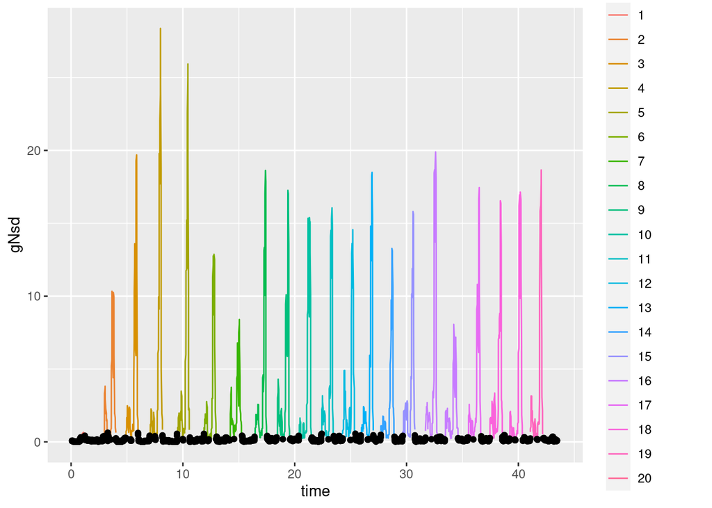

```r
library(ggplot2)
ggplot(X_long %>% filter(pid>0)) + geom_line(aes(x=time,y=gNsd,color=as.factor(pid),group=pid)) + geom_point(data=X_long %>% filter(pid==00),aes(x=time,y=gNsd),color="black")
```

When exporting the results of this processing the user wil; be asked to enter the group names and labels all the point with a pid !=0 will be labeled with the supplied label and the other with N for noise.

Some example of results are provided below.

```r
X_large=extract_feature_large(data,0.2,0.2,0.5)
str(X_large)
```

```
FALSE tibble [7 × 19] (S3: tbl_df/tbl/data.frame)
FALSE  $ pid       : num [1:7] 2 3 4 5 6 7 9
FALSE  $ gFx_mean_0: num [1:7] 0.449 1.545 0.985 1.081 1.26 ...
FALSE  $ gFx_mean_1: num [1:7] 1.584 -0.514 1.255 1.687 0.23 ...
FALSE  $ gFx_mean_2: num [1:7] 1.52 3.85 1.94 1.33 1.97 ...
FALSE  $ gFy_mean_0: num [1:7] 0.0812 -0.552 -0.954 -1.4069 -0.2105 ...
FALSE  $ gFy_mean_1: num [1:7] -1.427 -2.244 -2.327 -1.885 -0.785 ...
FALSE  $ gFy_mean_2: num [1:7] -0.0488 -1.5786 -0.3127 0.0058 -1.3311 ...
FALSE  $ gFz_mean_0: num [1:7] 1.208 1.101 1.212 0.984 1.021 ...
FALSE  $ gFz_mean_1: num [1:7] 0.185 0.281 0.41 0.363 0.805 ...
FALSE  $ gFz_mean_2: num [1:7] -0.323 0.165 0.623 -0.302 0.199 ...
FALSE  $ wx_mean_0 : num [1:7] 1.794 -0.427 1.01 0.736 -0.191 ...
FALSE  $ wx_mean_1 : num [1:7] -0.8684 0.3917 0.0518 -0.6859 -0.0461 ...
FALSE  $ wx_mean_2 : num [1:7] 0.0632 -0.4992 -1.1101 0.1435 -1.3258 ...
FALSE  $ wy_mean_0 : num [1:7] -1.622 0.682 1.312 2.319 -1.819 ...
FALSE  $ wy_mean_1 : num [1:7] -0.519 0.649 1.002 0.728 -2.06 ...
FALSE  $ wy_mean_2 : num [1:7] 0.627 -0.167 -1.18 1.742 0.938 ...
FALSE  $ wz_mean_0 : num [1:7] -2.432 -1.159 -3.153 -4.604 -0.619 ...
FALSE  $ wz_mean_1 : num [1:7] 5.437 -0.289 3.673 5.258 -5.199 ...
FALSE  $ wz_mean_2 : num [1:7] 2.03 9.74 2.98 1.54 6.27 ...
```

When exporting the results of this processing the user will be asked to enter the group names and labels.

## Process the three files and send the results.

# Outputs

- shiny app on shinyapps.io
- email with app code, app url, 3 input files and 6 output files
- use a coherent naming scheme for the files : NAME1_NAME2_NAME3_INPUT_X.csv,NAME1_NAME2_NAME3_INPUT_O.csv, NAME1_NAME2_NAME3_INPUT_N.csv for the input files of X, O and Noise and NAME1_NAME2_NAME3_OUTPUT_LARGE_X.csv, NAME1_NAME2_NAME3_OUTPUT_LONG_X.csv